# Re-analysis of GEO GSE54825: transcriptional response of engineered *Saccharomyces cerevisiae* to cellobiose versus glucose

A reproducible pipeline with a quantitative comparison to the original publication

Author

ApaTitee

Published

2026-09-14

# 1 Background

*Saccharomyces cerevisiae* cannot metabolise cellobiose. Engineering a heterologous cellobiose utilisation pathway — a cellodextrin transporter (cdt-1) and an intracellular β-glucosidase (gh1-1) from *Neurospora crassa* — enables growth on this sugar, but fermentation remains slower than on glucose (Galazka et al. 2010). The original study of the data set re-analysed here (GEO GSE54825; (Lin et al. 2014)) profiled the transcriptome of the engineered strain on cellobiose versus glucose under anaerobic conditions and reported 519 differentially expressed genes, mitochondrial activation, reduced amino-acid and thiamine biosynthesis, and two engineering leads (SUT1 overexpression, HAP4 deletion).

That study was analysed with a commercial platform (CLC Genomics Workbench 6.5), a private reference assembly, and a statistical framework (Baggerley’s test) that is no longer standard. This report re-analyses the same raw reads with a modern, fully scripted pipeline and asks a question the original could not answer: **how much of the original result is reproducible, and what is not assessable at all?**

# 2 Research question

What is the global transcriptional difference between cellobiose- and glucose-grown engineered *S. cerevisiae* under anaerobic exponential growth; which biological processes are involved; and which observations from the original study can be quantitatively reproduced with an independent pipeline?

# 3 Dataset

The seven input files (paper and supplements of both studies) are archived read-only with md5 checksums; the sequencing data are public and were verified against the md5 values published by ENA.

| sample_id | gsm | run | condition | replicate | layout | platform |
| --- | --- | --- | --- | --- | --- | --- |
| JCYL001B | GSM1324496 | SRR1166442 | glucose | 1 | SE | GAII |
| JCYL002B | GSM1324497 | SRR1166443 | glucose | 2 | SE | GAII |
| JCYL003B | GSM1324498 | SRR1166444 | glucose | 3 | SE | GAII |
| JCYL001D | GSM1324499 | SRR1166445 | cellobiose | 1 | SE | GAII |
| JCYL002D | GSM1324500 | SRR1166446 | cellobiose | 2 | SE | GAII |
| JCYL003D | GSM1324501 | SRR1166447 | cellobiose | 3 | SE | GAII |

| run | sample_id | condition | file | bytes | md5_self | md5_ena | status |
| --- | --- | --- | --- | --- | --- | --- | --- |
| SRR1166442 | JCYL001B | glucose | SRR1166442.fastq.gz | 1957980073 | 68e674b8a20e | 68e674b8a20e | PASS |
| SRR1166443 | JCYL002B | glucose | SRR1166443.fastq.gz | 2168810515 | dcc91f003612 | dcc91f003612 | PASS |
| SRR1166444 | JCYL003B | glucose | SRR1166444.fastq.gz | 1601609705 | f58e37e44319 | f58e37e44319 | PASS |
| SRR1166445 | JCYL001D | cellobiose | SRR1166445.fastq.gz | 2189433744 | a201447b2dda | a201447b2dda | PASS |
| SRR1166446 | JCYL002D | cellobiose | SRR1166446.fastq.gz | 1839997905 | 028b8c4edc3b | 028b8c4edc3b | PASS |
| SRR1166447 | JCYL003D | cellobiose | SRR1166447.fastq.gz | 1586975675 | cbb987dbfaa3 | cbb987dbfaa3 | PASS |

# 4 Experimental design

Two conditions × three biological replicates, a single batch, anaerobic exponential phase (80 g/L starting sugar, harvested at ≈50 g/L residual sugar). The original study used an unpaired two-group comparison; replicate numbering (`JCYL001B/001D`, …) hints at pairing but this cannot be verified from public metadata. The primary model is therefore unpaired (`~ condition`) and a paired model (`~ replicate + condition`) is run as a sensitivity analysis (see the *Differential expression* section). No spike-in controls and no independent batch are available.

# 5 Methods

| Step | Tool, version and settings |
| --- | --- |
| Raw data | ENA FTP download; md5 verified against ENA-published values |
| Read QC | FastQC 0.12.1; fastp 1.3.6 (light trimming, length >= 36 bp); MultiQC 1.35 |
| Reference (host) | RefSeq GCF_000146045.2 (S288C R64-1-1, 16 chromosomes + mitochondrion); transcripts extracted with gffread 0.12.9; annotation from the SGD GAF (release R64-5-1) |
| Reference (transgenes) | Host-vector-insert sequences adjudicated from the reads themselves (see the *Quantification* section) |
| Quantification | Salmon 2.7.0, decoy-aware index (k = 31; k = 25 as sensitivity), –libType A –gcBias –seqBias, fragment-length prior set to the observed read length (49 bp) |
| Gene-level matrix | tximport 1.34.0, countsFromAbundance = lengthScaledTPM |
| Differential expression | DESeq2 1.46.0; primary ~ condition, sensitivity ~ replicate + condition; LFC shrinkage (apeglm) for display only |
| Multiple testing | Benjamini-Hochberg |
| Functional enrichment | clusterProfiler 4.14.0 (ORA + GSEA) with self-built TERM2GENE tables; KEGG (sce) cached |
| Report | Quarto 1.9.38 (HTML; PDF via LaTeX/xelatex) |

# 6 Quality control

The 2014 data are single-end 50 bp reads from a Genome Analyzer II. FastQC reported Sanger/Illumina 1.9 encoding, so no Phred64 handling was required. Light trimming retained 95.1% of 238.6 million reads and raised the Q30 fraction from 0.88–0.93 to 0.93–0.96; adapter content is negligible (≈150 reads per sample after trimming, 0.01%).

*Read fate.* Reads were attributed in three tiers: (i) end-to-end alignment to the host genome plus transgenes (94.5–95.5%), (ii) local-mode re-alignment of the remainder (recovering 19.9–22.8% of the unmapped fraction, attributable to the strict end-to-end mode and to read errors in these older data), and (iii) a diagnostic reference containing the pRS426 backbone, the native 2 µm plasmid and TruSeq adapters (a further 35.6–40.4% of the residual). A small, quantified fraction (2.2–3.0% of the library) remains unexplained; candidate explanations are listed in the *Limitations* section. Multi-mapping is 23.0–24.9%, driven by Ty elements and the rDNA repeat, and the rDNA locus is the most deeply covered region of the reference (RDN25-1, mean depth 23×).

*Plasmid copy number.* Reads from the engineered plasmid backbone are 1.65× more abundant on cellobiose (10,385 → 17,188 reads per million), whereas reads from the native 2 µm plasmid are unchanged (3,358 → 3,012). This is independent evidence that any copy-number effect is specific to the engineered plasmid.

# 7 Quantification

The host reference and annotation were frozen (RefSeq `GCF_000146045.2`, SGD annotation release R64-5-1, all files md5-recorded). Two properties of this data set required specific handling.

**The transgenes are not what the literature suggests.** The RNA-seq samples carry pRS426-BT, whose inserts derive from *N. crassa* cDNA. Reads-derived consensus sequences match the public CDS of cdt-1 (NCU00801) and gh1-1 (NCU00130) base-for-base (0 differences). The codon-optimised `gh1-1a` published in the supplement (Figure S8) is **absent** from the samples (2 reads in 6 million) and differs from the native CDS at 25% of positions: using it as a reference would have silently destroyed transgene quantification. The C-terminal tag is a **superfolder GFP**: the consensus differs from the humanised EGFP CDS at only 7 nucleotides, and its translation carries all six superfolder substitutions (S30R/Y39N/N105T/Y145F/I171V/A206V) on an EGFP backbone. The cdt-1–tag junction was read directly from soft-clipped reads: `…GTTGCT` + `ATCGAT` (ClaI) + `GGTAGTGGTAGT` (Gly-Ser-Gly-Ser) + `GTGAGC…`, consistent with the cloning strategy described in the earlier work (Galazka et al. 2010). Because part of the transgene reference is derived from the sample reads, transgene results are reported **as ratios only**.

**Mitochondrially encoded genes must be measured, not assumed.** The RefSeq RNA FASTA contains no mitochondrial protein-coding mRNA, so transcripts were extracted from the GFF with gffread (6480 host transcripts, including 19 mitochondrial mRNAs) plus the two transgenes.

> **Reported `EffectiveLength` values are anomalous in Salmon 2.7.0 (Rust port)**: host transcripts receive a median effective length of 0.465 × length, and the transgene entries receive values above 10 × length. This does not affect the conclusions above; the checks in (i)–(iii) and the decoy comparison were performed specifically to bound the risk, and all transgene statements are based on ratios.

# 8 Sample-level analysis

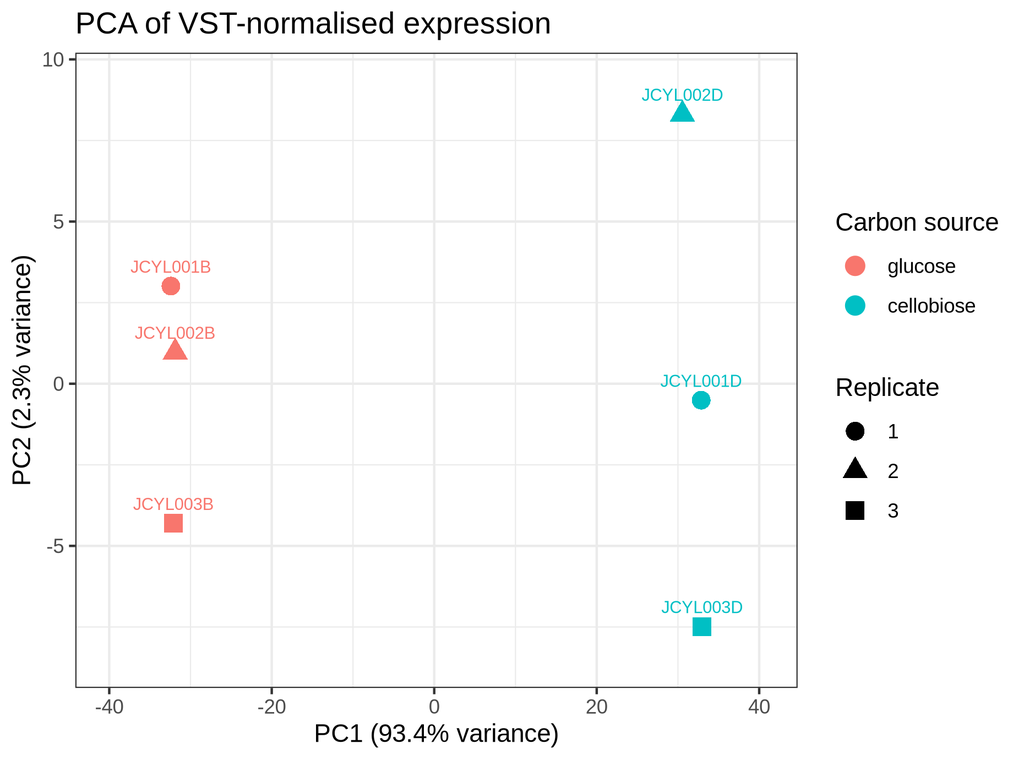

Figure 1: PCA of VST-normalised expression. Conditions separate on PC1 (93.4% of variance); within-condition replicates are tightly clustered (Spearman rho 0.994-0.998).

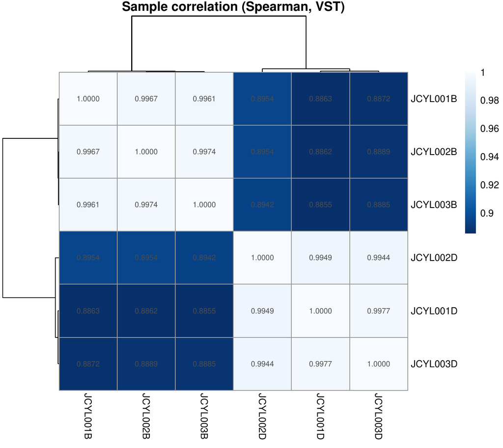

Figure 2: Sample-to-sample Spearman correlation of VST-normalised expression.

| item | value |
| --- | --- |
| n_genes_used | 6049 |
| PC1_var_pct | 93.4 |
| PC2_var_pct | 2.3 |
| within_glucose_spearman_min | 0.9961 |
| within_glucose_spearman_max | 0.9974 |
| within_cellobiose_spearman_min | 0.9944 |
| within_cellobiose_spearman_max | 0.9977 |
| between_condition_spearman_min | 0.8855 |
| between_condition_spearman_max | 0.8954 |
| separation_verdict | conditions separated on PC1 |

Conditions separate on PC1 (93.4% of variance) and replicates within a condition are extremely concordant (Spearman ρ 0.994–0.998) compared with the between-condition range (0.886–0.895), supporting H0.

# 9 Differential expression

| model | n_tested | n_deg | n_up | n_down | n_transgene |
| --- | --- | --- | --- | --- | --- |
| ~condition (primary) | 6049 | 644 | 346 | 298 | 2 |
| ~condition relaxed | 6049 | 4583 | 2325 | 2258 | 2 |
| ~condition stringent | 6049 | 363 | 207 | 156 | 2 |
| ~condition FDR<=0.001 & \|LFC\|>=1 | 6049 | 632 | 341 | 291 | 2 |
| ~replicate+condition (paired) | 6049 | 643 | 347 | 296 | 2 |

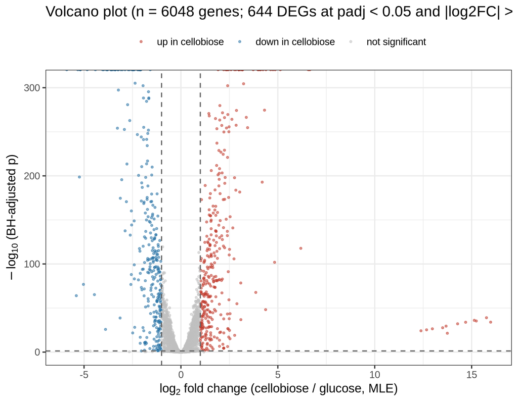

Figure 3: Volcano plot of the primary model (`~ condition`). Thresholds: BH-adjusted p < 0.05 and |log2FC| > 1; fold changes are unshrunken (MLE) values, which are the values used for all thresholding.

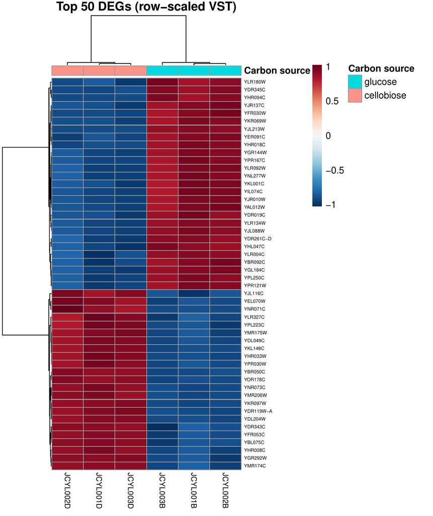

Figure 4: Row-scaled VST expression of the 50 most significant DEGs.

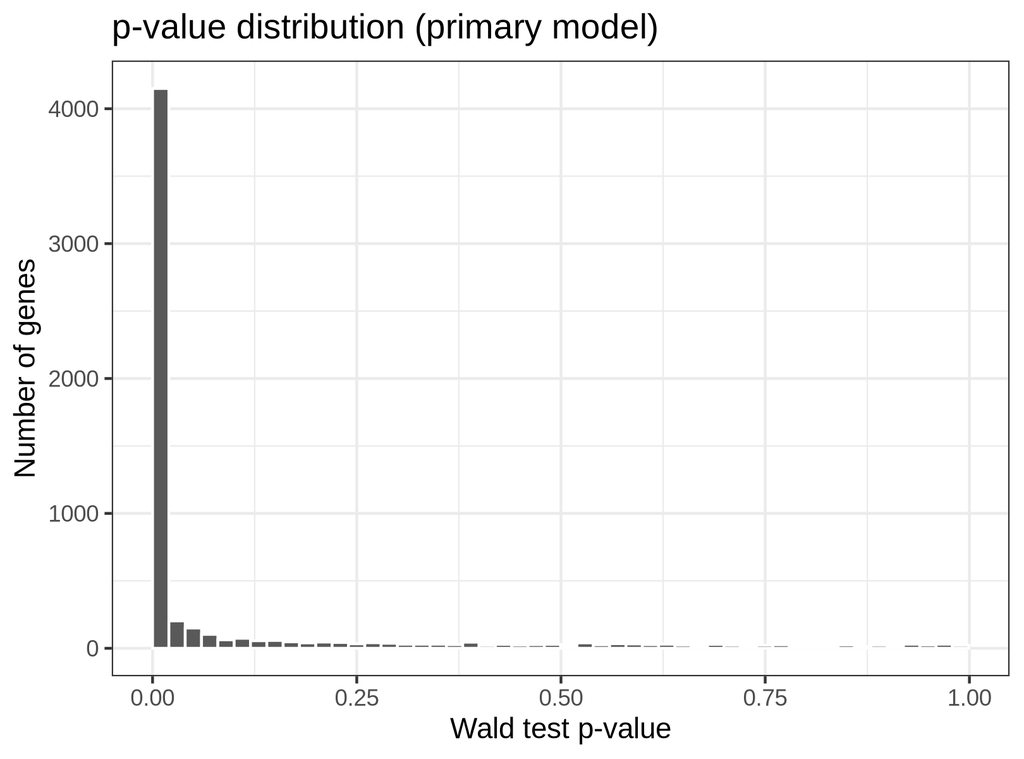

Figure 5: p-value distribution of the primary model (no systematic anti-conservatism; Cook’s cutoff exceeded by 1 of 6049 genes).

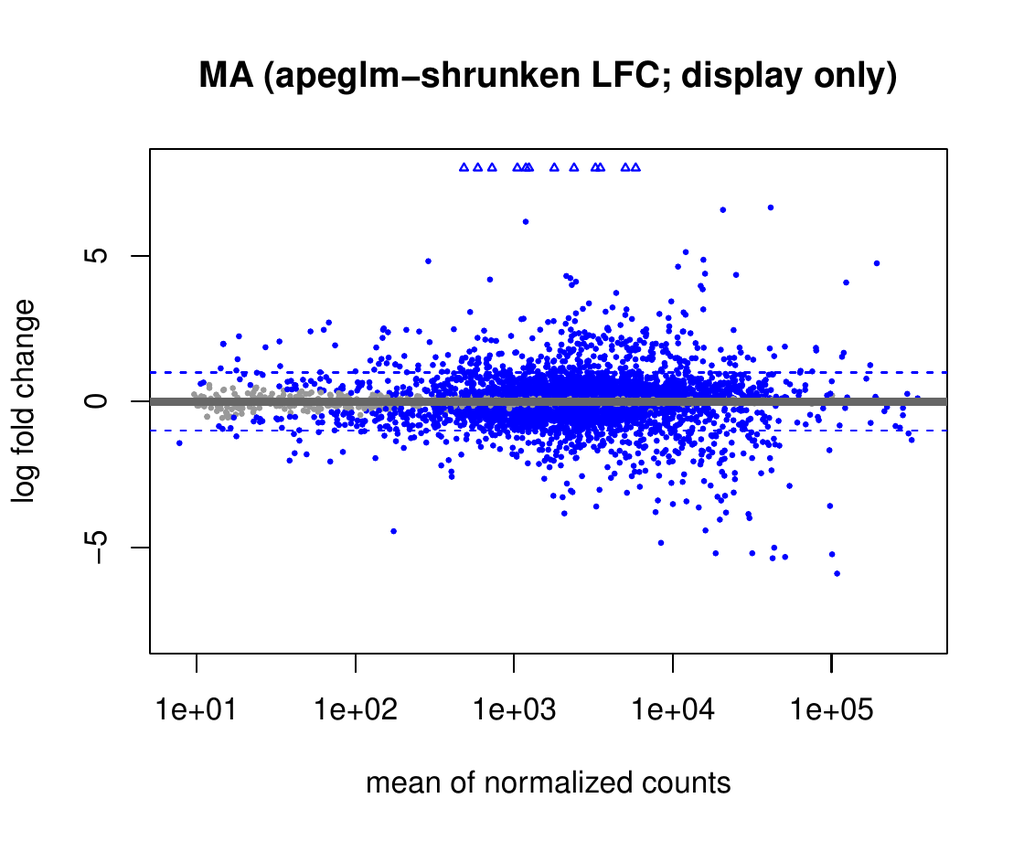

Figure 6: MA plot with apeglm-shrunken log2FC (display only; thresholding uses MLE values).

The primary model yields **644 DEGs** (346 up, 298 down); the tier matched to the original thresholds yields **632** (341 up, 291 down). The paired sensitivity model yields 643 DEGs and agrees with the primary model almost perfectly (Jaccard 0.986; 100% directional concordance; Pearson correlation of log2FC = 1.0000), so the conclusions do not depend on the pairing assumption. Model diagnostics show no systematic anti-conservatism and only one gene above the Cook’s distance cutoff.

# 10 Functional enrichment

| comparison | Description | GeneRatio | pvalue | p.adjust | Count |
| --- | --- | --- | --- | --- | --- |
| primary_DOWN_GOslim | amino acid metabolic process [GO:0006520] | 51/294 | 0.0e+00 | 0.00e+00 | 51 |
| primary_DOWN_GOslim | small molecule metabolic process [GO:0044281] | 86/294 | 0.0e+00 | 0.00e+00 | 86 |
| primary_DOWN_GOslim | sulfur compound metabolic process [GO:0006790] | 35/294 | 0.0e+00 | 0.00e+00 | 35 |
| primary_DOWN_GOslim | cytosol [GO:0005829] | 88/294 | 0.0e+00 | 0.00e+00 | 88 |
| primary_DOWN_GOslim | transmembrane transporter activity [GO:0022857] | 42/294 | 0.0e+00 | 4.00e-07 | 42 |
| primary_DOWN_GOslim | vitamin metabolic process [GO:0006766] | 14/294 | 0.0e+00 | 4.00e-07 | 14 |
| primary_DOWN_GOslim | monoatomic ion transport [GO:0006811] | 17/294 | 2.1e-06 | 4.31e-05 | 17 |
| primary_DOWN_GOslim | transmembrane transport [GO:0055085] | 31/294 | 2.2e-06 | 4.31e-05 | 31 |
| primary_UP_GOslim | respiratory chain complex [GO:0098803] | 36/316 | 0.0e+00 | 0.00e+00 | 36 |
| primary_UP_GOslim | generation of precursor metabolites and energy [GO:0006091] | 50/316 | 0.0e+00 | 0.00e+00 | 50 |
| primary_UP_GOslim | cellular respiration [GO:0045333] | 32/316 | 0.0e+00 | 0.00e+00 | 32 |
| primary_UP_GOslim | mitochondrion [GO:0005739] | 120/316 | 0.0e+00 | 0.00e+00 | 120 |
| primary_UP_GOslim | proton-transporting ATP synthase complex [GO:0045259] | 14/316 | 0.0e+00 | 0.00e+00 | 14 |
| primary_UP_GOslim | oxidoreductase activity [GO:0016491] | 52/316 | 0.0e+00 | 0.00e+00 | 52 |
| primary_UP_GOslim | transmembrane transporter activity [GO:0022857] | 54/316 | 0.0e+00 | 0.00e+00 | 54 |
| primary_UP_GOslim | respiratory chain complex III [GO:0045275] | 9/316 | 0.0e+00 | 0.00e+00 | 9 |
| threshold_matched_DOWN_GOslim | amino acid metabolic process [GO:0006520] | 51/289 | 0.0e+00 | 0.00e+00 | 51 |
| threshold_matched_DOWN_GOslim | small molecule metabolic process [GO:0044281] | 86/289 | 0.0e+00 | 0.00e+00 | 86 |
| threshold_matched_DOWN_GOslim | sulfur compound metabolic process [GO:0006790] | 35/289 | 0.0e+00 | 0.00e+00 | 35 |
| threshold_matched_DOWN_GOslim | cytosol [GO:0005829] | 88/289 | 0.0e+00 | 0.00e+00 | 88 |
| threshold_matched_DOWN_GOslim | transmembrane transporter activity [GO:0022857] | 42/289 | 0.0e+00 | 2.00e-07 | 42 |
| threshold_matched_DOWN_GOslim | vitamin metabolic process [GO:0006766] | 14/289 | 0.0e+00 | 4.00e-07 | 14 |
| threshold_matched_DOWN_GOslim | transmembrane transport [GO:0055085] | 31/289 | 1.5e-06 | 3.22e-05 | 31 |
| threshold_matched_DOWN_GOslim | monoatomic ion transport [GO:0006811] | 17/289 | 1.6e-06 | 3.22e-05 | 17 |
| threshold_matched_UP_GOslim | respiratory chain complex [GO:0098803] | 36/315 | 0.0e+00 | 0.00e+00 | 36 |
| threshold_matched_UP_GOslim | generation of precursor metabolites and energy [GO:0006091] | 50/315 | 0.0e+00 | 0.00e+00 | 50 |
| threshold_matched_UP_GOslim | cellular respiration [GO:0045333] | 32/315 | 0.0e+00 | 0.00e+00 | 32 |
| threshold_matched_UP_GOslim | mitochondrion [GO:0005739] | 120/315 | 0.0e+00 | 0.00e+00 | 120 |
| threshold_matched_UP_GOslim | proton-transporting ATP synthase complex [GO:0045259] | 14/315 | 0.0e+00 | 0.00e+00 | 14 |
| threshold_matched_UP_GOslim | oxidoreductase activity [GO:0016491] | 52/315 | 0.0e+00 | 0.00e+00 | 52 |
| threshold_matched_UP_GOslim | transmembrane transporter activity [GO:0022857] | 54/315 | 0.0e+00 | 0.00e+00 | 54 |
| threshold_matched_UP_GOslim | respiratory chain complex III [GO:0045275] | 9/315 | 0.0e+00 | 0.00e+00 | 9 |

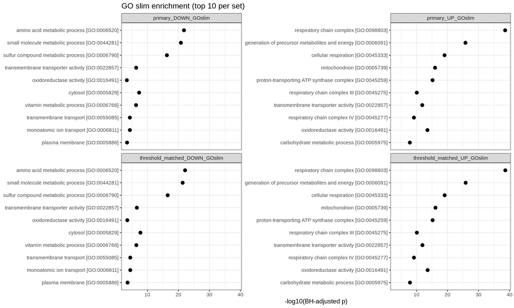

Figure 7: GO slim over-representation analysis (top 10 terms per gene set; BH-adjusted p).

| ID | Description | GeneRatio | pvalue | p.adjust | Count |
| --- | --- | --- | --- | --- | --- |
| sce00190 | Oxidative phosphorylation - Saccharomyces cerevisiae (budding yeast) | 44/250 | 0.00e+00 | 0.00e+00 | 44 |
| sce01110 | Biosynthesis of secondary metabolites - Saccharomyces cerevisiae (budding yeast) | 96/250 | 0.00e+00 | 0.00e+00 | 96 |
| sce01230 | Biosynthesis of amino acids - Saccharomyces cerevisiae (budding yeast) | 43/250 | 0.00e+00 | 0.00e+00 | 43 |
| sce00270 | Cysteine and methionine metabolism - Saccharomyces cerevisiae (budding yeast) | 19/250 | 0.00e+00 | 6.00e-07 | 19 |
| sce00340 | Histidine metabolism - Saccharomyces cerevisiae (budding yeast) | 10/250 | 1.00e-07 | 2.10e-06 | 10 |
| sce00670 | One carbon pool by folate - Saccharomyces cerevisiae (budding yeast) | 12/250 | 1.70e-06 | 2.32e-05 | 12 |
| sce01200 | Carbon metabolism - Saccharomyces cerevisiae (budding yeast) | 29/250 | 3.20e-06 | 3.86e-05 | 29 |
| sce00920 | Sulfur metabolism - Saccharomyces cerevisiae (budding yeast) | 9/250 | 5.00e-06 | 5.21e-05 | 9 |
| sce01210 | 2-Oxocarboxylic acid metabolism - Saccharomyces cerevisiae (budding yeast) | 15/250 | 1.03e-05 | 9.65e-05 | 15 |
| sce00220 | Arginine biosynthesis - Saccharomyces cerevisiae (budding yeast) | 10/250 | 1.29e-05 | 1.00e-04 | 10 |

| ID | Description | setSize | NES | pvalue | p.adjust |
| --- | --- | --- | --- | --- | --- |
| amino acid metabolic process | amino acid metabolic process | 222 | -2.65 | 0 | 0 |
| carboxylic acid biosynthetic process | carboxylic acid biosynthetic process | 181 | -2.65 | 0 | 0 |
| organic acid biosynthetic process | organic acid biosynthetic process | 181 | -2.65 | 0 | 0 |
| alpha-amino acid metabolic process | alpha-amino acid metabolic process | 159 | -2.66 | 0 | 0 |
| L-amino acid metabolic process | L-amino acid metabolic process | 147 | -2.64 | 0 | 0 |
| proteinogenic amino acid metabolic process | proteinogenic amino acid metabolic process | 147 | -2.64 | 0 | 0 |
| small molecule biosynthetic process | small molecule biosynthetic process | 343 | -2.32 | 0 | 0 |
| amino acid biosynthetic process | amino acid biosynthetic process | 119 | -2.65 | 0 | 0 |
| sulfur compound metabolic process | sulfur compound metabolic process | 146 | -2.59 | 0 | 0 |
| organic acid metabolic process | organic acid metabolic process | 354 | -2.23 | 0 | 0 |

The original study used FunSpec with Bonferroni correction (p 0.01); this re-analysis uses clusterProfiler with Benjamini–Hochberg correction and a self-built GO slim mapping (SGD `go_slim_mapping.tab`) as well as full GO annotations propagated to ancestor terms via the true path rule. The direction and identity of the enriched processes reproduce the original conclusions: upregulated genes are dominated by the respiratory chain, oxidative phosphorylation, ATP synthesis, mitochondrial and TCA-cycle terms, whereas downregulated genes are dominated by amino-acid biosynthesis (methionine, cysteine, arginine, histidine) and **thiamine (vitamin B1) biosynthesis**, with the same signal in KEGG (oxidative phosphorylation, biosynthesis of amino acids, cysteine/methionine and histidine metabolism).

# 11 Biological interpretation

| hypothesis | subtests | replicated | verdict |
| --- | --- | --- | --- |
| H0 | 1 | 1 | replicated |
| H1 | 5 | 5 | replicated |
| H2 | 6 | 6 | replicated |
| H3 | 3 | 1 | replicated (partial activation, as originally reported) |
| H4 | 1 | 1 | replicated |
| H5 | 2 | 1 | replicated |
| H6 | 1 | 1 | replicated |
| H7 | 1 | 1 | replicated |
| H8 | 3 | 3 | replicated |
| H9 | 1 | 1 | replicated |

| hypothesis | n_genes | mean_log2FC | wilcoxon_p | n_deg_in_set | fisher_p | verdict |
| --- | --- | --- | --- | --- | --- | --- |
| H0: global transcriptome separates by carbon.. | 6049 | NA | NA | NA | NA | replicated |
| H7: transgene mRNA is higher on cellobiose (.. | 2 | NA | NA | 2 | NA | replicated |
| H1: TCA cycle | 28 | 0.859 | 1.94e-04 | 11 | 8.11e-05 | replicated |
| H1: electron transport chain | 40 | 1.550 | 0.00e+00 | 29 | 0.00e+00 | replicated |
| H1: oxidative phosphorylation | 37 | 1.790 | 0.00e+00 | 29 | 0.00e+00 | replicated |
| H1: ATP synthesis coupled proton transport | 16 | 1.790 | 3.05e-05 | 15 | 0.00e+00 | replicated |
| H1: respiratory chain complex | 45 | 1.910 | 0.00e+00 | 38 | 0.00e+00 | replicated |
| H2: cellular amino acid biosynthetic process | 119 | -0.818 | 0.00e+00 | 50 | 0.00e+00 | replicated |
| H2: methionine biosynthetic process | 26 | -1.330 | 1.91e-05 | 13 | 7.00e-07 | replicated |
| H2: cysteine biosynthetic process | 5 | -2.170 | 6.25e-02 | 3 | 1.00e-02 | replicated |
| H2: arginine biosynthetic process | 13 | -1.480 | 1.22e-03 | 10 | 0.00e+00 | replicated |
| H2: histidine biosynthetic process | 8 | -1.060 | 1.56e-02 | 6 | 3.23e-05 | replicated |
| H2: thiamine biosynthetic process | 16 | -1.220 | 2.69e-03 | 7 | 7.64e-04 | replicated |
| H3: PKA pathway | 10 | 0.448 | 3.91e-03 | 0 | 6.13e-01 | replicated |
| H3: Snf3-Rgt2-Rgt1 | 5 | 0.047 | 1.00e+00 | 2 | 9.06e-02 | not_replicated |
| H3: Snf1-Mig1 | 5 | -0.054 | 8.12e-01 | 1 | 4.30e-01 | not_replicated |
| H4: hexose transporters | 11 | -0.138 | 9.66e-01 | 6 | 4.13e-04 | replicated |
| H5: SUT1 + ERG sterol genes | 21 | 0.058 | 7.85e-01 | 2 | 1.00e+00 | not_replicated |
| H5: DAN/TIR/PAU family | 26 | 0.580 | 3.34e-02 | 12 | 6.00e-06 | replicated |
| H6: storage carbon & gluconeogenesis | 8 | 1.120 | 2.34e-02 | 2 | 2.07e-01 | replicated |
| H9: ribosomal protein genes (growth-rate pro.. | 132 | 0.337 | 0.00e+00 | 1 | 5.00e-07 | replicated |
| H8: YGL162W (engineering candidate from H3/H5) | 1 | 2.140 | 0.00e+00 | NA | NA | replicated (differentially expressed) |
| H8: YKL109W (engineering candidate from H3/H5) | 1 | 2.630 | 0.00e+00 | NA | NA | replicated (differentially expressed) |
| H8: YKR034W (engineering candidate from H3/H5) | 1 | 1.220 | 0.00e+00 | NA | NA | replicated (differentially expressed) |

| estimator | gene | glucose_value | cellobiose_value | FC | note |
| --- | --- | --- | --- | --- | --- |
| salmon_CPM | cdt-1EGFP | 2260.0 | 4530.0 | 2.010 | mean of reads per million mapped (salmon) |
| salmon_CPM | gh1-1 | 1400.0 | 3260.0 | 2.320 | mean of reads per million mapped (salmon) |
| salmon_TPM | cdt-1EGFP | 26.8 | 75.7 | 2.820 | TPM (length-normalised, salmon) |
| salmon_TPM | gh1-1 | 26.4 | 84.4 | 3.190 | TPM (length-normalised, salmon) |
| URA3_proxy | URA3(YEL021W) | 432.0 | 589.0 | 1.360 | plasmid copy-number proxy (original anchor 1.354) |
| PGK1_control | PGK1(YCR012W) | NA | NA | 0.749 | same-promoter control (original anchor 0.745) |
| URA3_normalized | cdt-1EGFP | NA | NA | 1.470 | = CPM_FC / URA3_FC |
| URA3_normalized | gh1-1 | NA | NA | 1.700 | = CPM_FC / URA3_FC |
| original_RPKM | cdt-1EGFP | 877.0 | 1640.0 | 1.870 | original study anchor (Dataset S1) |
| original_RPKM | gh1-1 | 932.0 | 2010.0 | 2.160 | original study anchor (Dataset S1) |
| reads_1M_subsample | cdt-1 | 1390.0 | 2630.0 | 1.880 | adjudication experiment, bowtie2 read counts (PLAN 3.4.3) |
| reads_1M_subsample | gh1-1 | 1200.0 | 2680.0 | 2.220 | adjudication experiment, bowtie2 read counts (PLAN 3.4.3) |

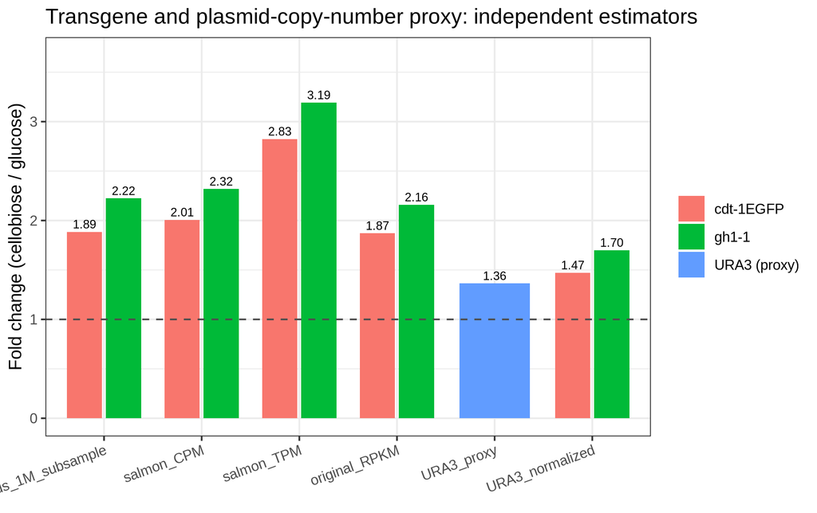

# 12 Comparison with the original study

| metric | value |
| --- | --- |
| genes_comparable_FC | 5770.000 |
| spearman_log2FC | 0.973 |
| pearson_log2FC | 0.840 |
| our_DEG_threshold_matched | 632.000 |
| original_DEG | 519.000 |
| overlap | 496.000 |
| jaccard | 0.757 |
| hypergeometric_p | 0.000 |
| direction_concordance_in_overlap | 1.000 |
| background_genes | 5780.000 |

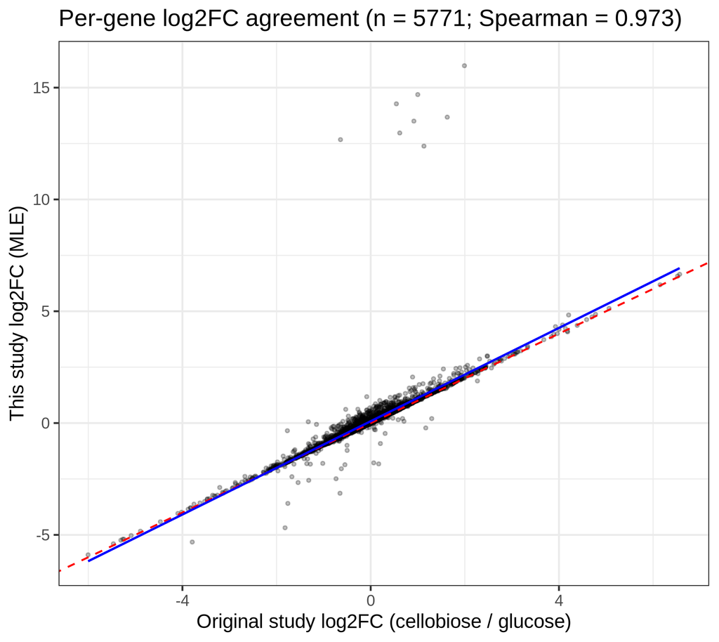

Figure 9: Per-gene log2FC agreement with the original study (Spearman = 0.973 over 5771 genes).

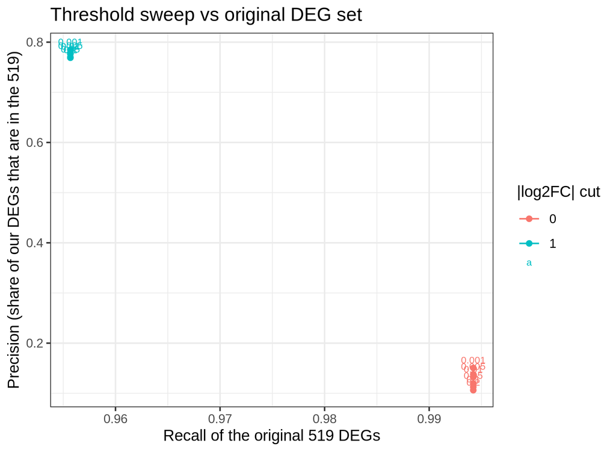

Figure 10: Precision/recall of the original 519 DEGs as a function of threshold.

| item | reason |
| --- | --- |
| mtDNA-encoded gene expression | poly-A selection captures yeast mitochondrial transcripts inefficiently; 5-18 chrM reads per 1e6; 0/19 mt genes reach 1x |
| absolute transgene abundance | the tag/junction part of the transgene reference is derived from the sample reads themselves (circularity) |
| absolute RPKM/TPM matching the original | CLC multi-mapping and 'By totals' RPKM are not reproducible outside CLC; only gene-level trends are comparable |
| cross-tool mapping statistics | original 92.3/83.4/76.3% were produced by CLC's internal algorithms; only order-of-magnitude comparison is meaningful |
| transgene C-terminal His6 cleavage state | requires protein-level data, out of scope |

| item | value | note | check |
| --- | --- | --- | --- |
| dataset_s1_rows_total | 6351 | Dataset S1 data rows (including the 2 transgene entries) | ok |
| dataset_s1_host_genes | 6349 | host gene entries | ok |
| dataset_s1_transgenes | 2 | transgene entries (cdt-1EGFP, gh1-1) | ok |
| dataset_s2_deg_rows | 519 | the 519 DEGs reported in the original study | ok |
| dataset_s2_deg_transgenes | 1 | transgene entries within the 519 (gh1-1) | ok |
| dataset_s2_tf_rows | 19 | 19 transcription factors | ok |
| dataset_s2_grn_rows | 7 | 7 GRN regulatory genes | ok |
| dataset_s3_go_terms_up | 12 | GO terms on the UP side | ok |
| dataset_s3_go_terms_down | 16 | GO terms on the DOWN side | ok |
| dataset_s3_up_genes | 244 | UP gene count declared in the Dataset S3 section header | ok |
| dataset_s3_down_genes | 256 | DOWN gene count declared in the Dataset S3 section header | ok |
| dataset_s3_notfound_up | 3 | genes not mapped by FunSpec on the UP side | ok |
| dataset_s3_notfound_down | 0 | genes not mapped by FunSpec on the DOWN side | ok |
| check_sum_of_parts | 503 | reconciliation: UP + DOWN + not-found on both sides | ok |
| check_gap_vs_519 | 16 | gap versus 519; explained in the report (the transgene gh1-1 carries no GO annotation) | ok |

Agreement is high at every level that can be compared:

[output not shown]

Absolute RPKM/TPM values cannot match the original: CLC’s internal multi-mapping handling is not reproducible outside CLC (only 76.3% of reads were uniquely mapped there), and percentages such as 92.3/83.4/76.3% are software-specific quantities. What is reproducible is the gene-level trend, and the trend is reproduced almost exactly.